# Human Activity Recognition

## Step 3 - Run each prediction model

### Naive Bayes

```r
nb_score <- do_cv(my.data, 'nb')
nb_score
```

```
## [1] 0.5950714 0.3262158 0.6098159 0.7668402
```

### Random Forest

```r
rf_score <- do_cv(my.data, 'rf')
rf_score
```

```
## [1] 0.3514163 0.2560030 0.5574633 0.5868136
```

### SVM

```r
svm_score <- do_cv(my.data, 'svm')
# svm_score <- do_cv(my.data, 'default')
svm_score
```

```
## [1] 0.5100723 0.5009119 0.5475631 0.7313593
```

### Multinomial Logistic Regression

```r
logreg_score <- do_cv(my.data, 'logreg')
logreg_score
```

```
## [1] 0.6431549 0.3718845 0.5046690 0.6490078
```

### Default predictor

```r
default_score <- do_cv(my.data, 'default')
default_score
```

```
## [1] 0.3027512 0.4363982 0.2867643 0.2934166
```

### Compare among different predictor

Prepare confident data frame with mean of cross validation for each classifier, at the same time, calculate confident interval at 0.95 confidence level.

```r
# Prepare for plot
model.name <- c("nb_score","rf_score","svm_score", "logreg_score", "default_score")
model.mean <- c(round(mean(nb_score), 2), round(mean(rf_score),2), round(mean(svm_score), 2), round(mean(logreg_score), 2), round(mean(default_score), 2))
t.test <- t.test(nb_score, conf.level = 0.95)
ci.l <- c(t.test$conf.int[1])
ci.h <- c(t.test$conf.int[2])
t.test <- t.test(rf_score, conf.level = 0.95)
ci.l <- c(ci.l, t.test$conf.int[1])
ci.h <- c(ci.h, t.test$conf.int[2])
t.test <- t.test(svm_score, conf.level = 0.95)
ci.l <- c(ci.l, t.test$conf.int[1])
ci.h <- c(ci.h, t.test$conf.int[2])
t.test <- t.test(logreg_score, conf.level = 0.95)
ci.l <- c(ci.l, t.test$conf.int[1])
ci.h <- c(ci.h, t.test$conf.int[2])
t.test <- t.test(default_score, conf.level = 0.95)
ci.l <- c(ci.l, t.test$conf.int[1])
ci.h <- c(ci.h, t.test$conf.int[2])
compare.scores <- data.frame(model.name, model.mean, ci.l, ci.h)
```

Plot the bar char to compare different classifier.

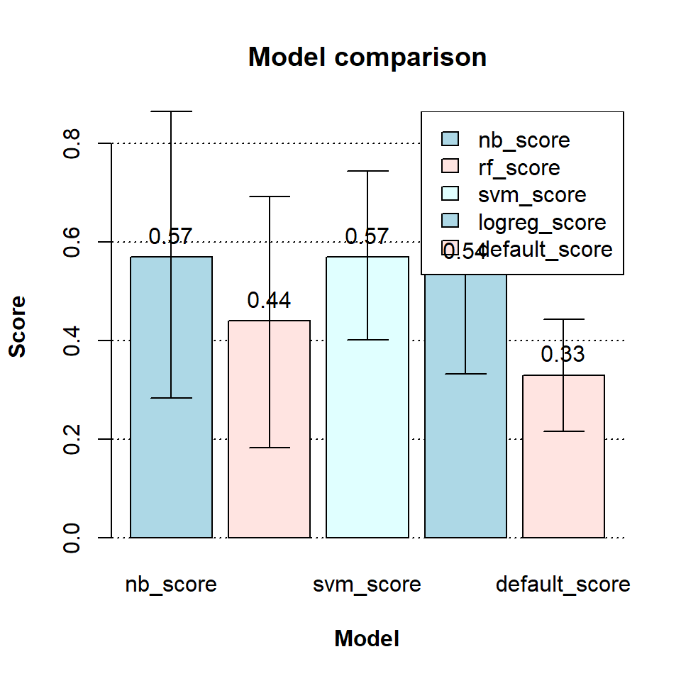

```r
# Plot barchart
bplot <- barplot2( compare.scores$model.mean,  # Data (bar heights) to plot
          beside = TRUE,  # Plot the bars beside one another; default is to plot stacked bars
          names.arg = compare.scores$model.name,  #Names for the bars
          col = c("lightblue", "mistyrose", "lightcyan"),  # Color of the bars
          border ="black",  # Color of the bar borders
          main = c("Model comparison"),  # Main title for the plot
          xlab = "Model",  # X-axis label
          ylab = "Score",  # Y-axis label
          font.lab = 2,  # Font to use for the axis labels: 1=plain text, 2=bold, 3=italic, 4=bold italic
          plot.ci = TRUE,  # Plot confidence intervals
          ci.l = compare.scores$ci.l,  # Lower values for the confidence interval
          ci.u = compare.scores$ci.h,  # Upper values for the confidence interval
          plot.grid = TRUE)  # Plot a grid
legend(   "topright",  # Add a legend to the plot
          legend = compare.scores$model.name,  # Text for the legend
          fill = c("lightblue", "mistyrose", "lightcyan"),  # Fill for boxes of the legend
          bg = "white")  # Background for legend box
text(bplot, compare.scores$model.mean, labels = compare.scores$model.mean, pos = 3)
```

# Feature Engineering

## Step 1 - Feature Extraction

The data set is consist of tri-axial accelerometers. For each accelerometer, Euler angles of roll, pitch, as well as the module (length) of the acceleartion vector can be extracted based on their tri-axial accelerometers.

```r
my.data <- transform(my.data,
                     pitch1 = with(my.data, atan2(-x1, sqrt(y1*y1 + z1*z1)) * 180 / pi),
                     roll1 = with(my.data, atan2(y1, z1) * 180 / pi),
                     module1 = with(my.data, sqrt(x1*x1 + y1*y1 + z1*z1)),
                     pitch2 = with(my.data, atan2(-x2, sqrt(y2*y2 + z2*z2)) * 180 / pi),
                     roll2 = with(my.data, atan2(y2, z2) * 180 / pi),
                     module2 = with(my.data, sqrt(x2*x2 + y2*y2 + z2*z2)),
                     pitch3 = with(my.data, atan2(-x3, sqrt(y3*y3 + z3*z3)) * 180 / pi),
                     roll3 = with(my.data, atan2(y3, z3) * 180 / pi),
                     module3 = with(my.data, sqrt(x3*x3 + y3*y3 + z3*z3)),
                     pitch4 = with(my.data, atan2(-x4, sqrt(y4*y4 + z4*z4)) * 180 / pi),
                     roll4 = with(my.data, atan2(y4, z4) * 180 / pi),
                     module4 = with(my.data, sqrt(x4*x4 + y4*y4 + z4*z4))
                     )
```

## Step 2 - Feature Segmentation

Meanwhile, I will also include variance, mean, standard deviation of each raw feature and derived feature in 10 consecutive record windows. This sliding windows approach will mitigate risk of overfitting by aggregating within windows.  
To avoid reducing record size, I consider rolling 10 data points aggregation of all records without skipping any record.

```r
my.data <- transform(my.data,
                     # First sensor
                     x1.mean = with(my.data, rollapply(zoo(x1), width = 10, FUN = mean, partial = 1)),
                     y1.mean = with(my.data, rollapply(zoo(y1), width = 10, FUN = mean, partial = 1)),
                     z1.mean = with(my.data, rollapply(zoo(z1), width = 10, FUN = mean, partial = 1)),
                     pitch1.mean = with(my.data, rollapply(zoo(pitch1), width = 10, FUN = mean, partial = 1)),
                     roll1.mean = with(my.data, rollapply(zoo(roll1), width = 10, FUN = mean, partial = 1)),
                     module1.mean = with(my.data, rollapply(zoo(module1), width = 10, FUN = mean, partial = 1)),
                     x1.var = with(my.data, rollapply(zoo(x1), width = 10, FUN = var, partial = 1)),
                     y1.var = with(my.data, rollapply(zoo(y1), width = 10, FUN = var, partial = 1)),
                     z1.var = with(my.data, rollapply(zoo(z1), width = 10, FUN = var, partial = 1)),
                     pitch1.var = with(my.data, rollapply(zoo(pitch1), width = 10, FUN = var, partial = 1)),
                     roll1.var = with(my.data, rollapply(zoo(roll1), width = 10, FUN = var, partial = 1)),
                     module1.var = with(my.data, rollapply(zoo(module1), width = 10, FUN = var, partial = 1)),
                     x1.sd = with(my.data, rollapply(zoo(x1), width = 10, FUN = sd, partial = 1)),
                     y1.sd = with(my.data, rollapply(zoo(y1), width = 10, FUN = sd, partial = 1)),
                     z1.sd = with(my.data, rollapply(zoo(z1), width = 10, FUN = sd, partial = 1)),
                     pitch1.sd = with(my.data, rollapply(zoo(pitch1), width = 10, FUN = sd, partial = 1)),
                     roll1.sd = with(my.data, rollapply(zoo(roll1), width = 10, FUN = sd, partial = 1)),
                     module1.sd = with(my.data, rollapply(zoo(module1), width = 10, FUN = sd, partial = 1)),

                     # Second sensor
                     x2.mean = with(my.data, rollapply(zoo(x2), width = 10, FUN = mean, partial = 1)),
                     y2.mean = with(my.data, rollapply(zoo(y2), width = 10, FUN = mean, partial = 1)),
                     z2.mean = with(my.data, rollapply(zoo(z2), width = 10, FUN = mean, partial = 1)),
                     pitch2.mean = with(my.data, rollapply(zoo(pitch2), width = 10, FUN = mean, partial = 1)),
                     roll2.mean = with(my.data, rollapply(zoo(roll2), width = 10, FUN = mean, partial = 1)),
                     module2.mean = with(my.data, rollapply(zoo(module2), width = 10, FUN = mean, partial = 1)),
                     x2.var = with(my.data, rollapply(zoo(x2), width = 10, FUN = var, partial = 1)),
                     y2.var = with(my.data, rollapply(zoo(y2), width = 10, FUN = var, partial = 1)),
                     z2.var = with(my.data, rollapply(zoo(z2), width = 10, FUN = var, partial = 1)),
                     pitch2.var = with(my.data, rollapply(zoo(pitch2), width = 10, FUN = var, partial = 1)),
                     roll2.var = with(my.data, rollapply(zoo(roll2), width = 10, FUN = var, partial = 1)),
                     module2.var = with(my.data, rollapply(zoo(module2), width = 10, FUN = var, partial = 1)),
                     x2.sd = with(my.data, rollapply(zoo(x2), width = 10, FUN = sd, partial = 1)),
                     y2.sd = with(my.data, rollapply(zoo(y2), width = 10, FUN = sd, partial = 1)),
                     z2.sd = with(my.data, rollapply(zoo(z2), width = 10, FUN = sd, partial = 1)),
                     pitch2.sd = with(my.data, rollapply(zoo(pitch2), width = 10, FUN = sd, partial = 1)),
                     roll2.sd = with(my.data, rollapply(zoo(roll2), width = 10, FUN = sd, partial = 1)),
                     module2.sd = with(my.data, rollapply(zoo(module2), width = 10, FUN = sd, partial = 1)),

                     # Third sensor
                     x3.mean = with(my.data, rollapply(zoo(x3), width = 10, FUN = mean, partial = 1)),
                     y3.mean = with(my.data, rollapply(zoo(y3), width = 10, FUN = mean, partial = 1)),
                     z3.mean = with(my.data, rollapply(zoo(z3), width = 10, FUN = mean, partial = 1)),
                     pitch3.mean = with(my.data, rollapply(zoo(pitch3), width = 10, FUN = mean, partial = 1)),
                     roll3.mean = with(my.data, rollapply(zoo(roll3), width = 10, FUN = mean, partial = 1)),
                     module3.mean = with(my.data, rollapply(zoo(module3), width = 10, FUN = mean, partial = 1)),
                     x3.var = with(my.data, rollapply(zoo(x3), width = 10, FUN = var, partial = 1)),
                     y3.var = with(my.data, rollapply(zoo(y3), width = 10, FUN = var, partial = 1)),
                     z3.var = with(my.data, rollapply(zoo(z3), width = 10, FUN = var, partial = 1)),
                     pitch3.var = with(my.data, rollapply(zoo(pitch3), width = 10, FUN = var, partial = 1)),
                     roll3.var = with(my.data, rollapply(zoo(roll3), width = 10, FUN = var, partial = 1)),
                     module3.var = with(my.data, rollapply(zoo(module3), width = 10, FUN = var, partial = 1)),
                     x3.sd = with(my.data, rollapply(zoo(x3), width = 10, FUN = sd, partial = 1)),
                     y3.sd = with(my.data, rollapply(zoo(y3), width = 10, FUN = sd, partial = 1)),
                     z3.sd = with(my.data, rollapply(zoo(z3), width = 10, FUN = sd, partial = 1)),
                     pitch3.sd = with(my.data, rollapply(zoo(pitch3), width = 10, FUN = sd, partial = 1)),
                     roll3.sd = with(my.data, rollapply(zoo(roll3), width = 10, FUN = sd, partial = 1)),
                     module3.sd = with(my.data, rollapply(zoo(module3), width = 10, FUN = sd, partial = 1)),

                     # Fourth sensor
                     x4.mean = with(my.data, rollapply(zoo(x4), width = 10, FUN = mean, partial = 1)),
                     y4.mean = with(my.data, rollapply(zoo(y4), width = 10, FUN = mean, partial = 1)),
                     z4.mean = with(my.data, rollapply(zoo(z4), width = 10, FUN = mean, partial = 1)),
                     pitch4.mean = with(my.data, rollapply(zoo(pitch4), width = 10, FUN = mean, partial = 1)),
                     roll4.mean = with(my.data, rollapply(zoo(roll4), width = 10, FUN = mean, partial = 1)),
                     module4.mean = with(my.data, rollapply(zoo(module4), width = 10, FUN = mean, partial = 1)),
                     x4.var = with(my.data, rollapply(zoo(x4), width = 10, FUN = var, partial = 1)),
                     y4.var = with(my.data, rollapply(zoo(y4), width = 10, FUN = var, partial = 1)),
                     z4.var = with(my.data, rollapply(zoo(z4), width = 10, FUN = var, partial = 1)),
                     pitch4.var = with(my.data, rollapply(zoo(pitch4), width = 10, FUN = var, partial = 1)),
                     roll4.var = with(my.data, rollapply(zoo(roll4), width = 10, FUN = var, partial = 1)),
                     module4.var = with(my.data, rollapply(zoo(module4), width = 10, FUN = var, partial = 1)),
                     x4.sd = with(my.data, rollapply(zoo(x4), width = 10, FUN = sd, partial = 1)),
                     y4.sd = with(my.data, rollapply(zoo(y4), width = 10, FUN = sd, partial = 1)),
                     z4.sd = with(my.data, rollapply(zoo(z4), width = 10, FUN = sd, partial = 1)),
                     pitch4.sd = with(my.data, rollapply(zoo(pitch4), width = 10, FUN = sd, partial = 1)),
                     roll4.sd = with(my.data, rollapply(zoo(roll4), width = 10, FUN = sd, partial = 1)),
                     module4.sd = with(my.data, rollapply(zoo(module4), width = 10, FUN = sd, partial = 1))
                     )
```

```r
dim(my.data)
```

```
## [1] 165632    103
```

## Step 3 - Feature Selection

In this section, I will use PCA to select the Top principal components that all together represents more than 95% of variance. By PCA approach, the number of features will be reduced, meanwhile, I also get rid of collinear features. Run feature selection by prcomp

```r
my.newdata <- feature_removal(my.data)  #remove features with user info
my.newdata <- subset(my.newdata, select=-c(class))
pca <- prcomp(my.newdata, scale = TRUE, center = TRUE)
```

Plot the scee plot which shows the distribution of variance contained in subsequent principal components sorted by their eigenvalues. As a result, 26 Principal Components explain about 95 % of total variance. So by using PCA, the dimensions are reduces from 96 to 26.

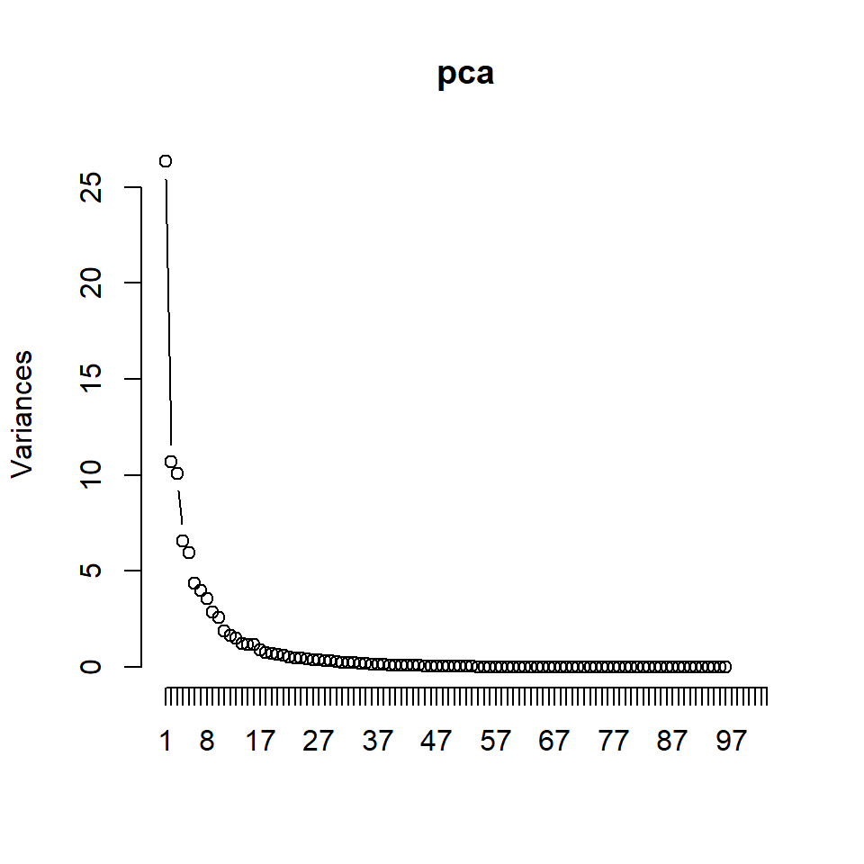

```r
screeplot(pca, npcs = 103, type = "lines")
```

```r
ev <- pca$sdev^2  # get eigenvalues by taking sdev squares, eigenvalues are variance in this case
# ev <- apply(pca$x, 2, var)  # alternative way to get eigenvalue
props <- ev/ sum(ev)
cumprops <- cumsum(props)
df <- data.frame(N = 1:length(cumprops), cumprops = cumprops)
min(which(df$cumprops > 0.95))
```

```
## [1] 26
```

Create a second plot showing cumulative variance retained if top N components are kept after dimensionality reduction

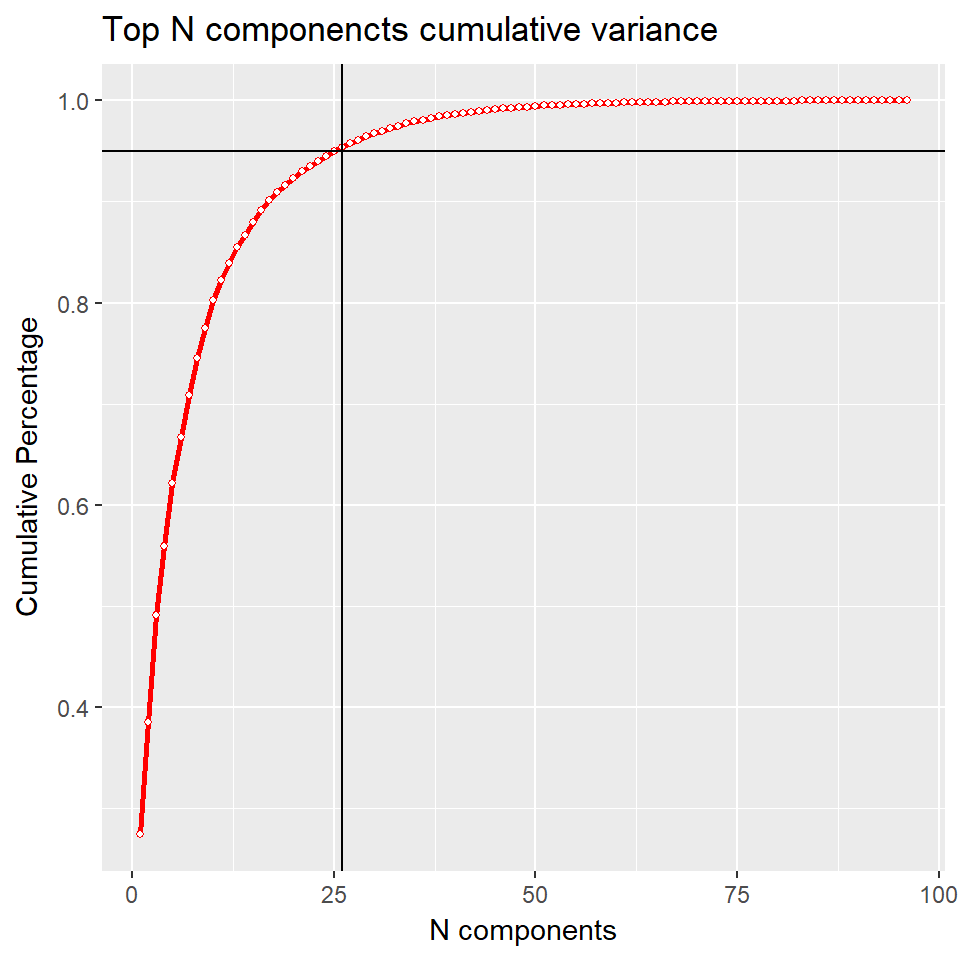

```r
ggplot(df, aes(x = N, y = cumprops)) +
  geom_line(colour="red", size=1) +
  geom_point(colour="red", size=1, shape=21, fill="white") +
  xlab("N components") + ylab("Cumulative Percentage") +
  ggtitle("Top N componencts cumulative variance") +
  geom_hline(yintercept=0.95)+
  geom_vline(xintercept=26)
```

# Classification

This section is similar to the preliminary classification, upgraded with features engineering.

## Step 1 - Feature Removal

The user based features are not important in this practise, because it only affects who the users are rather than defining user behaviors. This function will remove unnessasory features from the dataset.

```r
feature_removal_2 <- function(df) {
  df <- subset(df, select=-c(user))
  return(df)
}
```

## Step 2 - Cross Validation

Here I need to make a little bit improvement to include PCA features. Also, I need to retain user for 4 folds cross validation.

```r
my.pca <- data.frame(user = my.data$user, pca$x[,c(1:26)], class = my.data$class)  # Retain User for 4 folds cross validation
do_cv_upgrade <- function(df, model) {
  nn <- nrow(df)  # number of data points
  nf <- ncol(df)  # number of features
  df <- df[,c(which(colnames(df) != "class"), which(colnames(df) == "class"))]  # Move output to the last column
  folds <- split(1:nn, df[,c(which(colnames(df) == "user"))])  # user split.by column to split folds.
  score <- rep(NA, length(folds))  # create a list to hold the mse for each folds
  df <- feature_removal_2(df)
  for (ii in 1:length(folds)) {
    test.index <- folds[[ii]]  # extract test index
    train.data <- df[-test.index, ]  # assemble training data
    test.data <- df[test.index, ]  # assemble test data
    if (model == 'nb') {
      fit <- naiveBayes(formula = class ~ ., data = train.data)
      pred <- predict(fit, test.data)
    } else if (model == 'rf') {
      fit <- randomForest(formula = class ~ ., data = train.data, ntree = 100, mtry = 2, importance = TRUE)
      pred <- predict(fit, test.data)
    } else if (model == 'svm') {
      fit <- svm(formula = class ~ ., data = train.data)
      pred <- predict(fit, test.data)
    } else if (model == 'logreg') {
      fit <- multinom(formula = class ~ ., data = train.data)
      pred <- predict(fit, test.data)
    } else if (model == 'default') {
      pred <- rep(names(which.max(table(train.data$class))), nrow(test.data))  # Default is the majority of the ouput
    }
    accuracy <- sum(pred == test.data$class)/length(pred)
    score[ii] <- accuracy  # save the score
  }
  return(score)
}
```

## Step 3 - Run each prediction model

### Naive Bayes

```r
nb_score <- do_cv_upgrade(my.pca, 'nb')
nb_score
```

```
## [1] 0.7393993 0.4605623 0.3549210 0.6386356
```

### Random Forest

```r
rf_score <- do_cv_upgrade(my.pca, 'rf')
rf_score
```

```
## [1] 0.8237780 0.8351064 0.5960801 0.6450742
```

### SVM

```r
svm_score <- do_cv_upgrade(my.pca, 'svm')
# svm_score <- do_cv_upgrade(my.pca, 'default')
svm_score
```

```
## [1] 0.8067356 0.6460486 0.8035825 0.8384673
```

### Multinomial Logistic Regression

```r
logreg_score <- do_cv_upgrade(my.pca, 'logreg')
logreg_score
```

```
## [1] 0.8709115 0.6304711 0.6751812 0.8737328
```

### Default predictor

```r
default_score <- do_cv_upgrade(my.pca, 'default')
default_score
```

```
## [1] 0.3027512 0.4363982 0.2867643 0.2934166
```

### Compare among different predictor

Prepare confident data frame with mean of cross validation for each classifier, at the same time, calculate confident interval at 0.95 confidence level.

```r
# Prepare for plot
model.name <- c("nb_score","rf_score","svm_score", "logreg_score", "default_score")
model.mean <- c(round(mean(nb_score), 2), round(mean(rf_score),2), round(mean(svm_score), 2), round(mean(logreg_score), 2), round(mean(default_score), 2))
t.test <- t.test(nb_score, conf.level = 0.95)
ci.l <- c(t.test$conf.int[1])
ci.h <- c(t.test$conf.int[2])
t.test <- t.test(rf_score, conf.level = 0.95)
ci.l <- c(ci.l, t.test$conf.int[1])
ci.h <- c(ci.h, t.test$conf.int[2])
t.test <- t.test(svm_score, conf.level = 0.95)
ci.l <- c(ci.l, t.test$conf.int[1])
ci.h <- c(ci.h, t.test$conf.int[2])
t.test <- t.test(logreg_score, conf.level = 0.95)
ci.l <- c(ci.l, t.test$conf.int[1])
ci.h <- c(ci.h, t.test$conf.int[2])
t.test <- t.test(default_score, conf.level = 0.95)
ci.l <- c(ci.l, t.test$conf.int[1])
ci.h <- c(ci.h, t.test$conf.int[2])
compare.scores <- data.frame(model.name, model.mean, ci.l, ci.h)
```

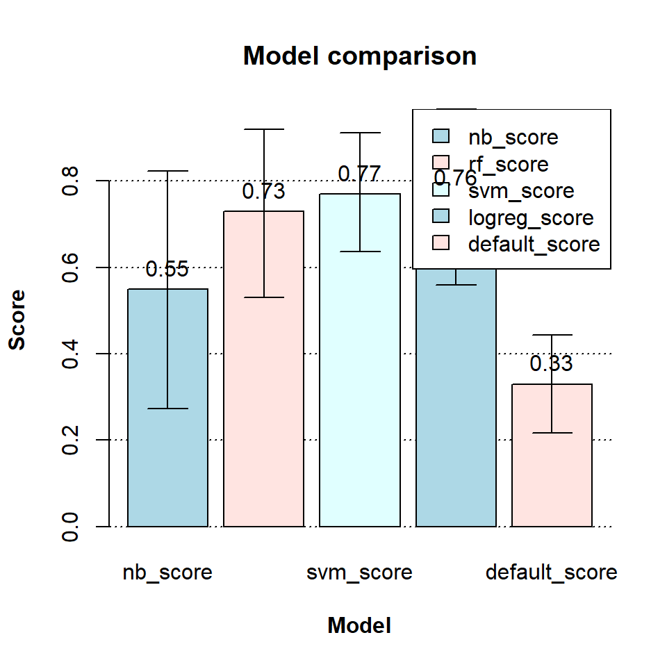

```r
# Plot barchart
bplot <- barplot2( compare.scores$model.mean,  # Data (bar heights) to plot
          beside = TRUE,  # Plot the bars beside one another; default is to plot stacked bars
          names.arg = compare.scores$model.name,  #Names for the bars
          col = c("lightblue", "mistyrose", "lightcyan"),  # Color of the bars
          border ="black",  # Color of the bar borders
          main = c("Model comparison"),  # Main title for the plot
          xlab = "Model",  # X-axis label
          ylab = "Score",  # Y-axis label
          font.lab = 2,  # Font to use for the axis labels: 1=plain text, 2=bold, 3=italic, 4=bold italic
          plot.ci = TRUE,  # Plot confidence intervals
          ci.l = compare.scores$ci.l,  # Lower values for the confidence interval
          ci.u = compare.scores$ci.h,  # Upper values for the confidence interval
          plot.grid = TRUE)  # Plot a grid
legend(   "topright",  # Add a legend to the plot
          legend = compare.scores$model.name,  # Text for the legend
          fill = c("lightblue", "mistyrose", "lightcyan"),  # Fill for boxes of the legend
          bg = "white")  # Background for legend box
text(bplot, compare.scores$model.mean, labels = compare.scores$model.mean, pos = 3)
```